# Relationship between MBTI personality types and physical traits

Project task for Statistical Data Analysis course at University of Zagreb, Faculty of Electrical Engineering and Computing

Tina Bakić, Luka Korov, Dora Baričević, Roko Grbelja

2024-01-21

# Introduction

## Libraries

```r
library(hexbin)
library(dplyr)
```

## Dataset

Dataset contains physical and personality data of 97 randomly sampled subjects. All subjects were French-Canadian, living in Canada between the Québec and Sorel-Tracy areas. The Biotonix analyses and report were used on the subjects being tested in order to distinguish postural deviations. Personality was determined by using the Myers-Briggs Type Indicator questionnaire.

Gathered data includes following characteristics for all subjects:

| Column name | Description |
| --- | --- |
| AGE | age in years |
| HEIGHT | height in inches |
| WEIGHT | weight in pounds |
| SEX | biological gender (female/male) |
| ACTIVITY.LEVEL | physical activity level (low/moderate/high) |
| PAIN.1 | level of neck pain (0-100) |
| PAIN.2 | level of pain in upper back (0-100) |
| PAIN.3 | level of pain in middle back (0-100) |
| PAIN.4 | level of pain in lower back (0-100) |
| MBTI | Myers-Briggs personality type |
| E | level of extraversion |
| I | level of introversion |
| S | level of sensing |
| N | level of intuition |
| T | level of thinking |
| F | level of feeling |
| J | level of judging |
| P | level of perceiving |
| POSTURE | posutre type (A - ideal, B - kyphosis-lordosis, C - flat back, D - sway-back) |

```r
dataset_mbti <- read.csv("datasets/MBTI.csv")
```

### Transformations

1. to metric system + BMI

```r
dataset_mbti$HEIGHT_CM <- dataset_mbti$HEIGHT * 2.54
dataset_mbti$WEIGHT_KG <- dataset_mbti$WEIGHT * 0.453592
dataset_mbti$BMI <- dataset_mbti$WEIGHT_KG / (dataset_mbti$HEIGHT_CM / 100)^2
```

2. separating each personality trait

```r
dataset_mbti$MBTI_EI <- substring(dataset_mbti$MBTI, 1, 1)
dataset_mbti$MBTI_SN <- substring(dataset_mbti$MBTI, 2, 2)
dataset_mbti$MBTI_TF <- substring(dataset_mbti$MBTI, 3, 3)
dataset_mbti$MBTI_JP <- substring(dataset_mbti$MBTI, 4, 4)
```

3. from categories to numerical

```r
dataset_mbti$SEX_INT <- match(dataset_mbti$SEX, c("Female", "Male"))
dataset_mbti$ACTIVITY.LEVEL_INT <- match(dataset_mbti$ACTIVITY.LEVEL, c("Low", "Moderate", "High"))
dataset_mbti$POSTURE_INT <- match(dataset_mbti$POSTURE, c("A", "B", "C", "D"))
```

4. grouping similar personality types

```r
dataset_mbti %>%
        mutate(MBTI_GROUP = case_when(
                MBTI == "INTJ" | MBTI == "INTP" | MBTI == "ENTJ" | MBTI == "ENTP" ~ "Analyst",
                MBTI == "INFJ" | MBTI == "INFP" | MBTI == "ENFJ" | MBTI == "ENFP" ~ "Diplomat",
                MBTI == "ISTJ" | MBTI == "ISFJ" | MBTI == "ESTJ" | MBTI == "ESFJ" ~ "Sentinel",
                MBTI == "ISTP" | MBTI == "ISFP" | MBTI == "ESTP" | MBTI == "ESFP" ~ "Explorer"
        ))
```

```
##     X S.No AGE HEIGHT WEIGHT    SEX ACTIVITY.LEVEL PAIN.1 PAIN.2 PAIN.3 PAIN.4
## 1   0    1  53     62    125 Female            Low    0.0    0.0    0.0    0.0
## 2   1    2  52     69    157   Male           High    7.0    8.0    5.0    3.0
## 3   2    3  30     69    200   Male           High    0.0    0.0    0.0    0.0
## 4   3    4  51     66    175   Male       Moderate    9.5    9.5    9.5    1.5
## 5   4    5  45     63    199 Female       Moderate    4.0    5.0    2.0    2.0
## 6   5    6  68     74    182   Male            Low    0.0    2.5    1.5    0.0
## 7   6    7  62     68    263   Male            Low    7.0   10.0   10.0   10.0
## 8   7    8  65     61    143 Female            Low    0.0    9.0    5.0   10.0
## 9   8    9  66     67    180   Male            Low    0.5    3.5    0.5    9.5
## 10  9   10  58     69    165   Male            Low    0.0    7.5    7.0    3.0
## 11 10   11  61     67    210   Male            Low    5.0    0.0    0.0    9.0
## 12 11   12  33     62    120 Female            Low    0.0    3.0    0.0    0.0
## 13 12   13  48     64    127 Female            Low    5.0    7.0    8.0    7.0
## 14 13   14  57     68    185   Male            Low    2.5    7.5    1.5    5.5
```

[output cut: 377 more lines]

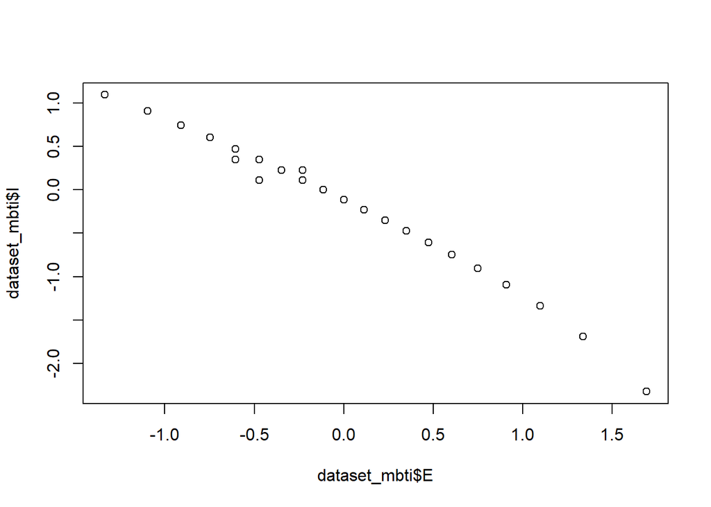

```r
plot(dataset_mbti$E, dataset_mbti$I)
```

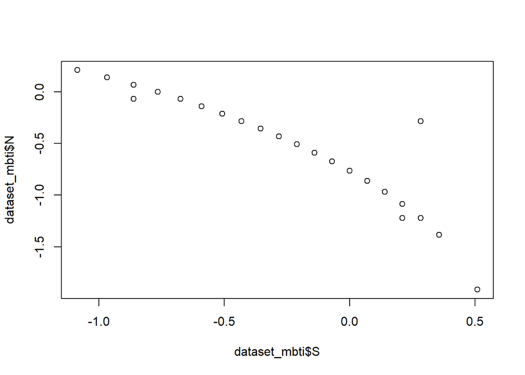

```r
plot(dataset_mbti$S, dataset_mbti$N)
```

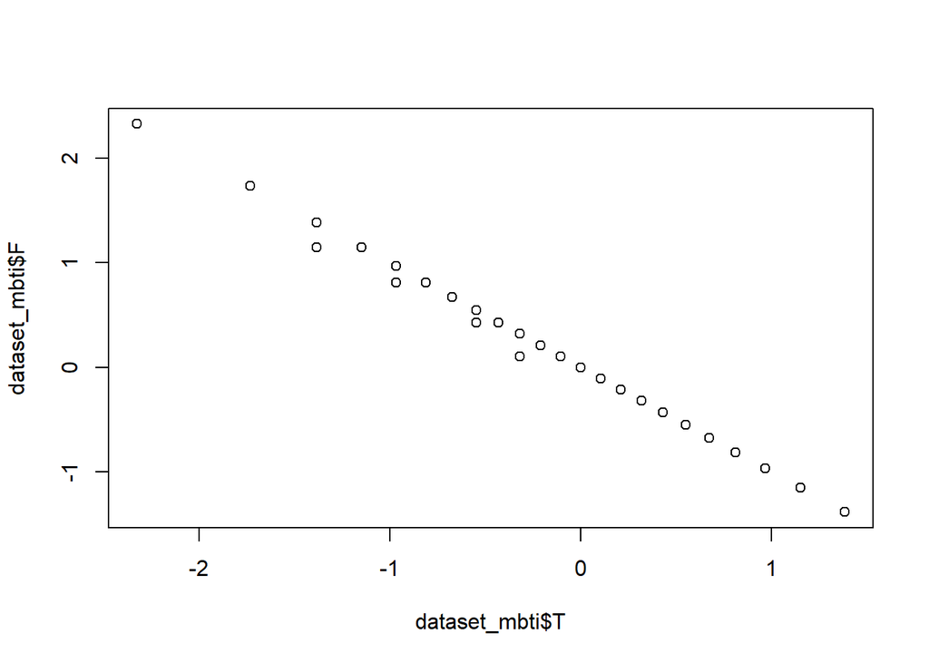

```r
plot(dataset_mbti$T, dataset_mbti$F)
```

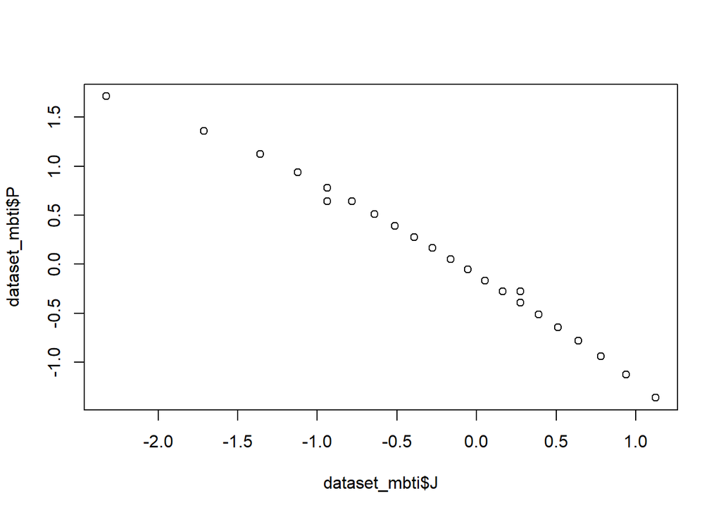

```r
plot(dataset_mbti$J, dataset_mbti$P)
```

## Research questions

1. Is there a connection between personality type and posture?
2. Are physically active people also more extroverted?
3. Is there a difference in height/weight based on personality type?
4. Can you predict a personality type or a specific personality characteristic based on physical traits?
5. Are women more feeling than men?
6. Is there a connection between generation (age) and personality types?

# RQ-1: Is there a connection between personality type and posture?

*[HR]* Postoji li veza izmedu tipa ličnosti i načina držanja?

kategorije sa 16personalities.com

## For MBTI Personality Type:

**H0:** There is no association between the individual personality trait and posture.

**H1:** There is an association between the individual personality trait and posture.

```r
mbti_posture_table <- table(dataset_mbti$POSTURE, dataset_mbti$MBTI)
mbti_posture_table
```

```
##
##     ENFJ ENFP ENTJ ENTP ESFJ ESFP ESTJ ESTP INFJ INFP INTJ ISFJ ISFP ISTJ ISTP
##   A    1    8    0    1    1    5    2    3    0    0    0    1    0    0    0
##   B    3    2    2    3    6    5    3    6    1    0    0    1    0    2    2
##   C    1    0    1    1    2    2    0    1    1    2    1    3    2    1    1
##   D    0    0    2    0    2    0    2    0    2    3    0    0    5    3    1
```

```r
chi_squared_test_mbti <- chisq.test(mbti_posture_table)
chi_squared_test_mbti
```

```
##
##  Pearson's Chi-squared test
##
## data:  mbti_posture_table
## X-squared = 75.806, df = 42, p-value = 0.001072
```

p-value = 0.001072 < significance-level = 0.05

### Conclusion

The p-value of the Chi-squared test is lower than the significance level, therefore, we reject the null hypothesis and conclude that there is a significant correlation between an individual’s personality type and their posture. It is important to note that the Chi-squared approximation may not be correct as our sample size is relatively small and our contingency table is large and data is sparse. We can try and remedy this by aggregating the posture types into two categories: GOOD and BAD.

```r
dataset_mbti$POSTURE_AGG <- ifelse(dataset_mbti$POSTURE == "A", "GOOD", "BAD")
table(dataset_mbti$POSTURE_AGG)
```

```
##
##  BAD GOOD
##   75   22
```

```r
mbti_posture_agg_table <- table(dataset_mbti$POSTURE_AGG, dataset_mbti$MBTI)

chi_squared_test_mbti_agg <- chisq.test(mbti_posture_agg_table)
chi_squared_test_mbti_agg
```

```
##
##  Pearson's Chi-squared test
##
## data:  mbti_posture_agg_table
## X-squared = 32.253, df = 14, p-value = 0.003687
```

## For individual personality traits:

**H0:** There is no association between the individual personality trait and posture.

**H1:** There is an association between the individual personality trait and posture.

```r
ei_posture_table <- table(dataset_mbti$POSTURE, dataset_mbti$MBTI_EI)
sn_posture_table <- table(dataset_mbti$POSTURE, dataset_mbti$MBTI_SN)
tf_posture_table <- table(dataset_mbti$POSTURE, dataset_mbti$MBTI_TF)
jp_posture_table <- table(dataset_mbti$POSTURE, dataset_mbti$MBTI_JP)
```

```r
chi_squared_test_ei <- chisq.test(ei_posture_table)
chi_squared_test_ei
```

```
##
##  Pearson's Chi-squared test
##
## data:  ei_posture_table
## X-squared = 30.114, df = 3, p-value = 1.306e-06
```

```r
chi_squared_test_sn <- chisq.test(sn_posture_table)
chi_squared_test_sn
```

```
##
##  Pearson's Chi-squared test
##
## data:  sn_posture_table
## X-squared = 1.3296, df = 3, p-value = 0.7221
```

```r
chi_squared_test_tf <- chisq.test(tf_posture_table)
chi_squared_test_tf
```

```
##
##  Pearson's Chi-squared test
##
## data:  tf_posture_table
## X-squared = 3.5441, df = 3, p-value = 0.3151
```

```r
chi_squared_test_jp <- chisq.test(jp_posture_table)
chi_squared_test_jp
```

```
##
##  Pearson's Chi-squared test
##
## data:  jp_posture_table
## X-squared = 6.0148, df = 3, p-value = 0.1109
```

### Conclusion

Out of the 4 personality traits, only the extroversion/introversion trait passes the chi-squared test on the significance level of 0.05. We reject the null hypothesis for the extroversion/introversion personality trait and conclude that there is a significant connection between an individual’s extrovertedness and their posture.

If we try and visualize the extroversion scores for each posture type, it is apparent that extroverted individuals tend to have better posture.

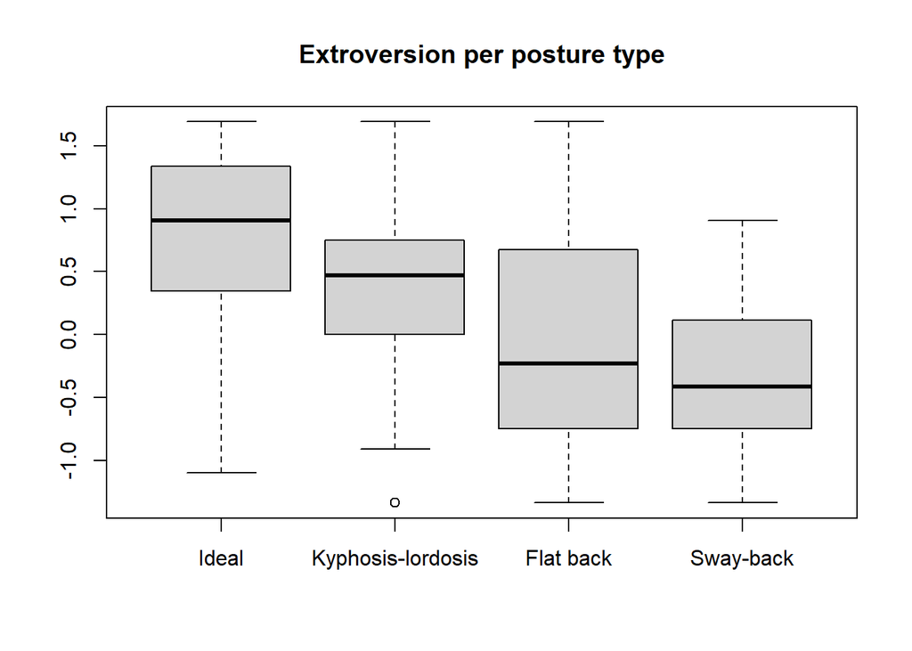

```r
boxplot(dataset_mbti[dataset_mbti$POSTURE == "A", ]$E,
        dataset_mbti[dataset_mbti$POSTURE == "B", ]$E,
        dataset_mbti[dataset_mbti$POSTURE == "C", ]$E,
        dataset_mbti[dataset_mbti$POSTURE == "D", ]$E,
        names = c("Ideal", "Kyphosis-lordosis", "Flat back", "Sway-back"),
        main = "Extroversion per posture type"
)
```

# RQ-2: Are physically active people also more extroverted?

*[HR]* Jesu li fizički aktivniji ljudi također i ekstrovertiraniji?

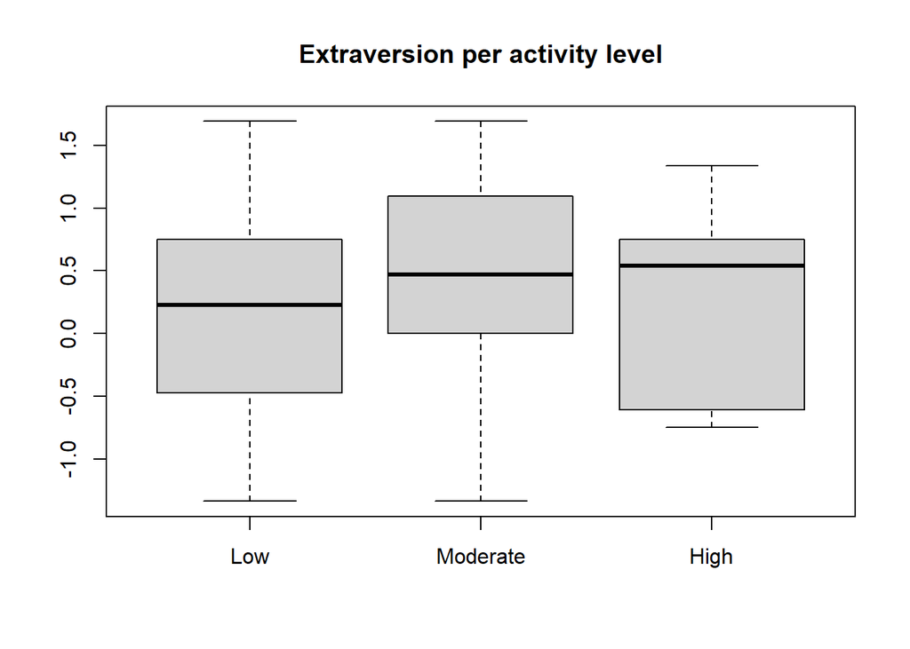

```r
boxplot(dataset_mbti[dataset_mbti$ACTIVITY.LEVEL == "Low",]$E,
        dataset_mbti[dataset_mbti$ACTIVITY.LEVEL == "Moderate",]$E,
        dataset_mbti[dataset_mbti$ACTIVITY.LEVEL == "High",]$E,
        names = c("Low", "Moderate", "High"),
        main = "Extraversion per activity level")
```

## ANOVA

H0: There is no significant difference in mean extraversion scores among people with different activity levels (Low, Moderate, High).

H1: At least one pair of activity levels has significantly different mean extraversion scores.

```r
extraversion_scores <- dataset_mbti$E[dataset_mbti$MBTI_EI == "E"]

low_activity <- dataset_mbti$E[dataset_mbti$ACTIVITY.LEVEL == "Low"]
moderate_activity <- dataset_mbti$E[dataset_mbti$ACTIVITY.LEVEL == "Moderate"]
high_activity <- dataset_mbti$E[dataset_mbti$ACTIVITY.LEVEL == "High"]

anova_result <- aov(E ~ ACTIVITY.LEVEL, data = dataset_mbti)

summary(anova_result)
```

```
##                Df Sum Sq Mean Sq F value Pr(>F)
## ACTIVITY.LEVEL  2   0.76  0.3811   0.592  0.555
## Residuals      94  60.53  0.6439
```

p-value = 0.555 > significance level = 0.05

We cannot reject null hypothesis. There isn’t enough evidence to conclude that there are significant differences in extraversion scores among individuals with different activity levels.

## Independency

H0: Activity levels and extraversion are independent of each other.

H1: Activity levels and extraversion are not independent of each other, there is a relationship between them.

```r
contingency_table <- table(dataset_mbti$ACTIVITY.LEVEL, dataset_mbti$MBTI_EI)
contingency_table
```

```
##
##             E  I
##   High      4  2
##   Low      48 26
##   Moderate 13  4
```

```r
chi_sq_test <- chisq.test(contingency_table)
print(chi_sq_test)
```

```
##
##  Pearson's Chi-squared test
##
## data:  contingency_table
## X-squared = 0.84264, df = 2, p-value = 0.6562
```

p-value = 0.6562 > significance level = 0.05

We cannot reject null hypothesis. There isn’t enough evidence to conclude that extraversion and different activity levels are not independant.

## Conclusion

There is not enough evidence to say that physically active people are also more extroverted.

# RQ-3: Is there a difference in height/weight based on personality type?

*[HR]* Postoji li razlika u visini/težini ljudi s obzirom na tip ličnosti?

Box plot check

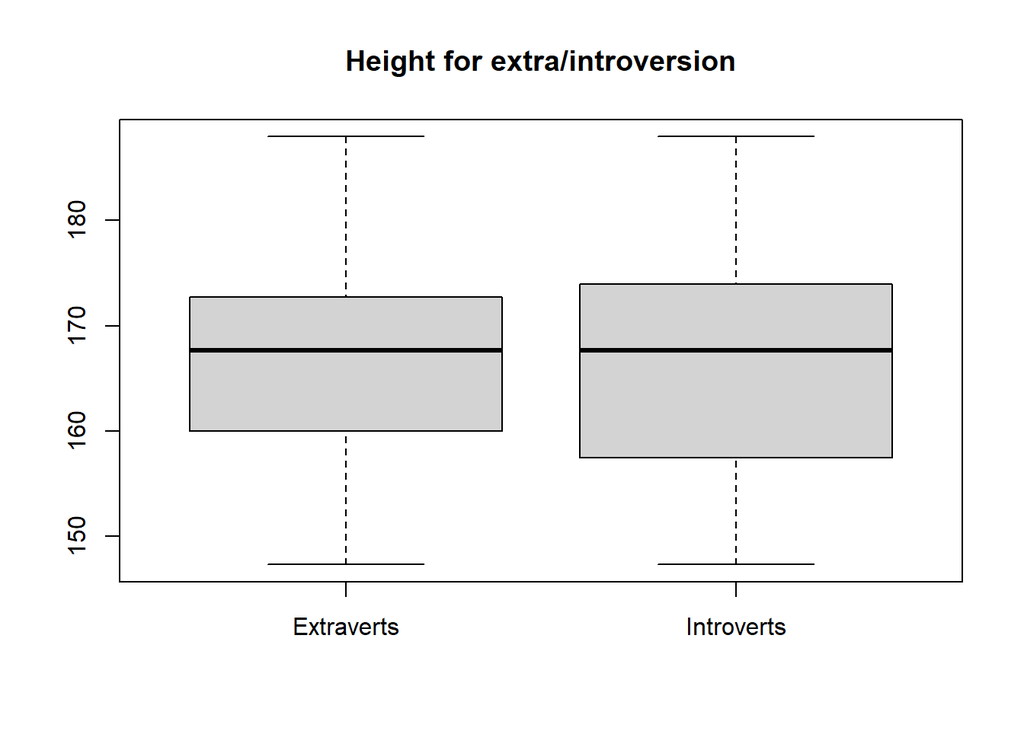

```r
boxplot(dataset_mbti[dataset_mbti$MBTI_EI == "E",]$HEIGHT_CM,
        dataset_mbti[dataset_mbti$MBTI_EI == "I",]$HEIGHT_CM,
        names = c("Extraverts", "Introverts"),
        main = "Height for extra/introversion")
```

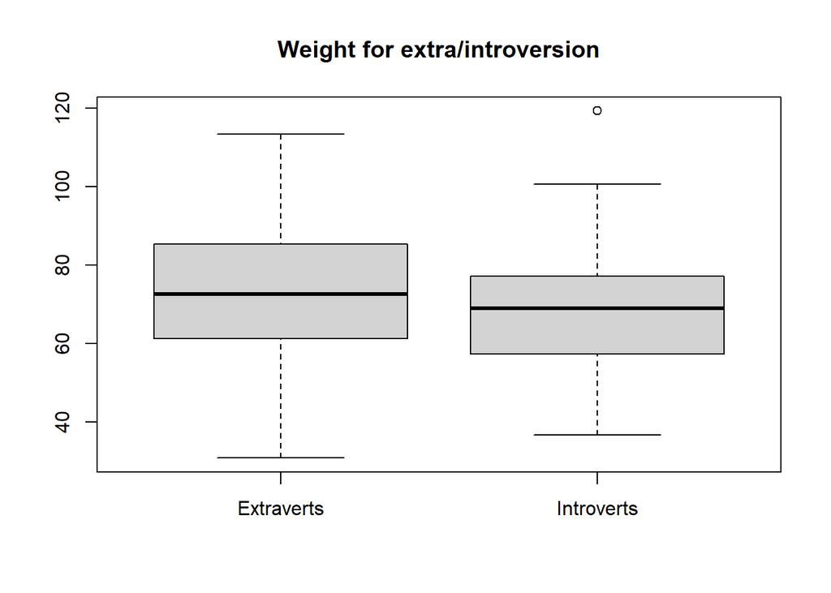

```r
boxplot(dataset_mbti[dataset_mbti$MBTI_EI == "E",]$WEIGHT_KG,
        dataset_mbti[dataset_mbti$MBTI_EI == "I",]$WEIGHT_KG,
        names = c("Extraverts", "Introverts"),
        main = "Weight for extra/introversion")
```

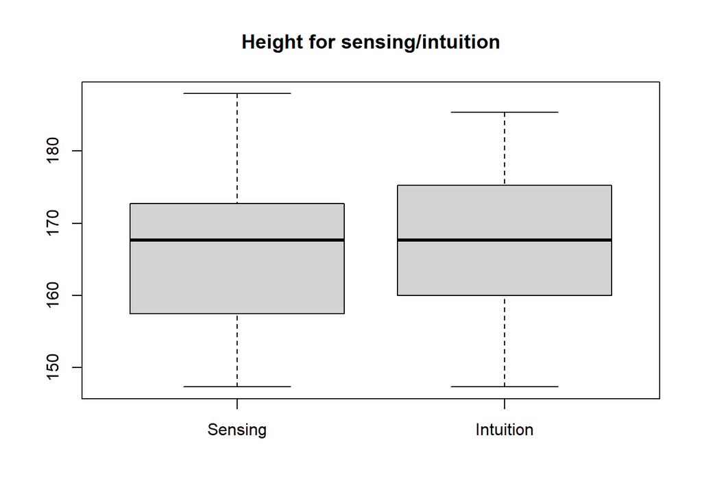

```r
boxplot(dataset_mbti[dataset_mbti$MBTI_SN == "S",]$HEIGHT_CM,
        dataset_mbti[dataset_mbti$MBTI_SN == "N",]$HEIGHT_CM,
        names = c("Sensing", "Intuition"),
        main = "Height for sensing/intuition")
```

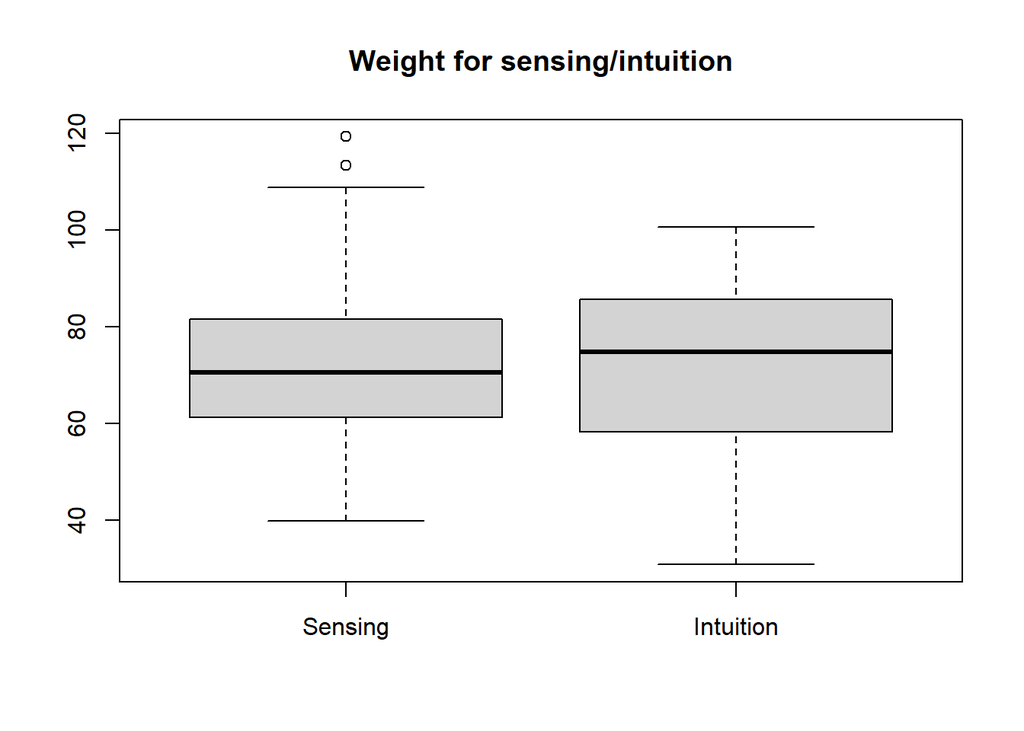

```r
boxplot(dataset_mbti[dataset_mbti$MBTI_SN == "S",]$WEIGHT_KG,
        dataset_mbti[dataset_mbti$MBTI_SN == "N",]$WEIGHT_KG,
        names = c("Sensing", "Intuition"),
        main = "Weight for sensing/intuition")
```

Normality check

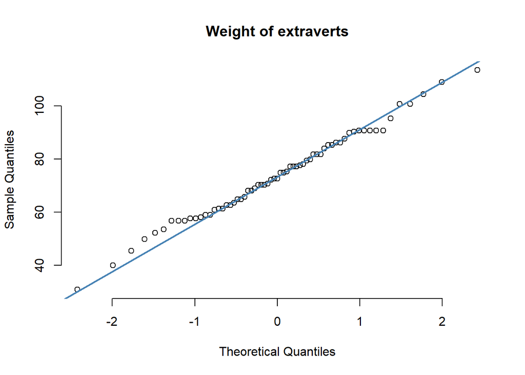

```r
qqnorm(dataset_mbti[dataset_mbti$MBTI_EI == "E",]$WEIGHT_KG,
       pch = 1, frame = FALSE,
       main='Weight of extraverts')
qqline(dataset_mbti[dataset_mbti$MBTI_EI == "E",]$WEIGHT_KG,
       col = "steelblue", lwd = 2)
```

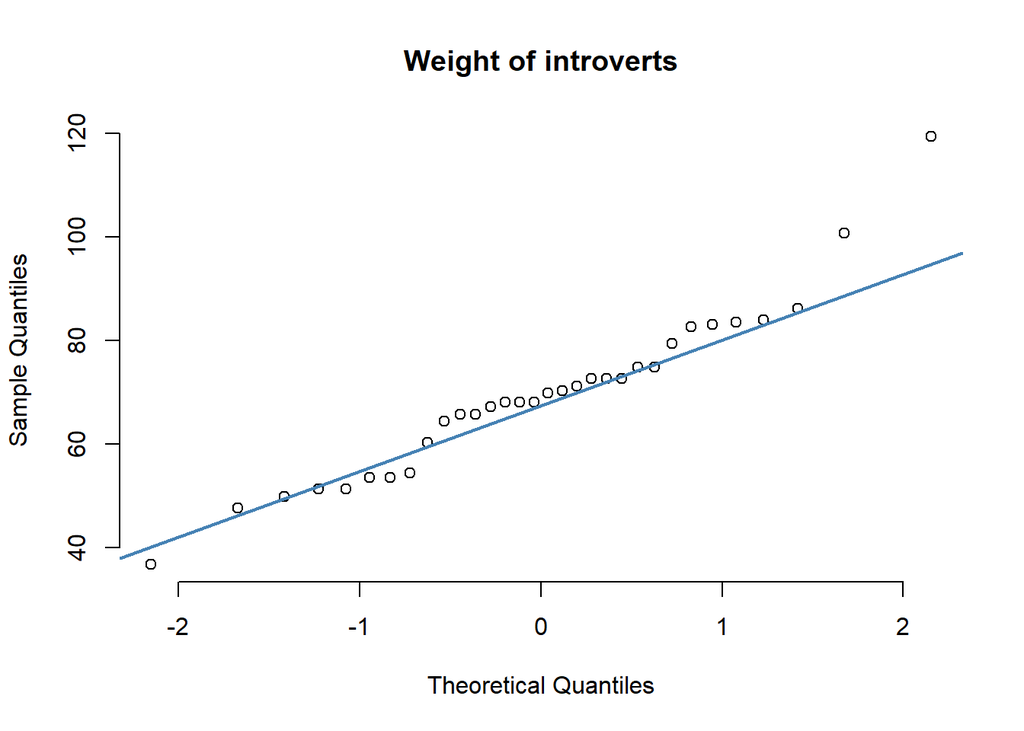

```r
qqnorm(dataset_mbti[dataset_mbti$MBTI_EI == "I",]$WEIGHT_KG,
       pch = 1, frame = FALSE,
       main='Weight of introverts')
qqline(dataset_mbti[dataset_mbti$MBTI_EI == "I",]$WEIGHT_KG,
       col = "steelblue", lwd = 2)
```

Variant equality check

```r
var.test(dataset_mbti[dataset_mbti$MBTI_EI == "E",]$WEIGHT_KG, dataset_mbti[dataset_mbti$MBTI_EI == "I",]$WEIGHT_KG)
```

```
##
##  F test to compare two variances
##
## data:  dataset_mbti[dataset_mbti$MBTI_EI == "E", ]$WEIGHT_KG and dataset_mbti[dataset_mbti$MBTI_EI == "I", ]$WEIGHT_KG
## F = 1.0283, num df = 64, denom df = 31, p-value = 0.9573
## alternative hypothesis: true ratio of variances is not equal to 1
## 95 percent confidence interval:
##  0.5374664 1.8411156
## sample estimates:
## ratio of variances
##            1.02828
```

T-test with equal/different variants

```r
t.test(dataset_mbti[dataset_mbti$MBTI_EI == "E",]$WEIGHT_KG, dataset_mbti[dataset_mbti$MBTI_EI == "I",]$WEIGHT_KG, alt = "greater", var.equal = TRUE)
```

```
##
##  Two Sample t-test
##
## data:  dataset_mbti[dataset_mbti$MBTI_EI == "E", ]$WEIGHT_KG and dataset_mbti[dataset_mbti$MBTI_EI == "I", ]$WEIGHT_KG
## t = 1.2011, df = 95, p-value = 0.1164
## alternative hypothesis: true difference in means is greater than 0
## 95 percent confidence interval:
##  -1.627033       Inf
## sample estimates:
## mean of x mean of y
##  73.71917  69.47045
```

# RQ-4: Can you predict a personality type or a specific personality characteristic based on physical traits?

*[HR]* Možete li pomoću danih značajki naslutiti tip ličnosti ili rezultat na pojedinoj karakteristici?

Linear regression for E/I values

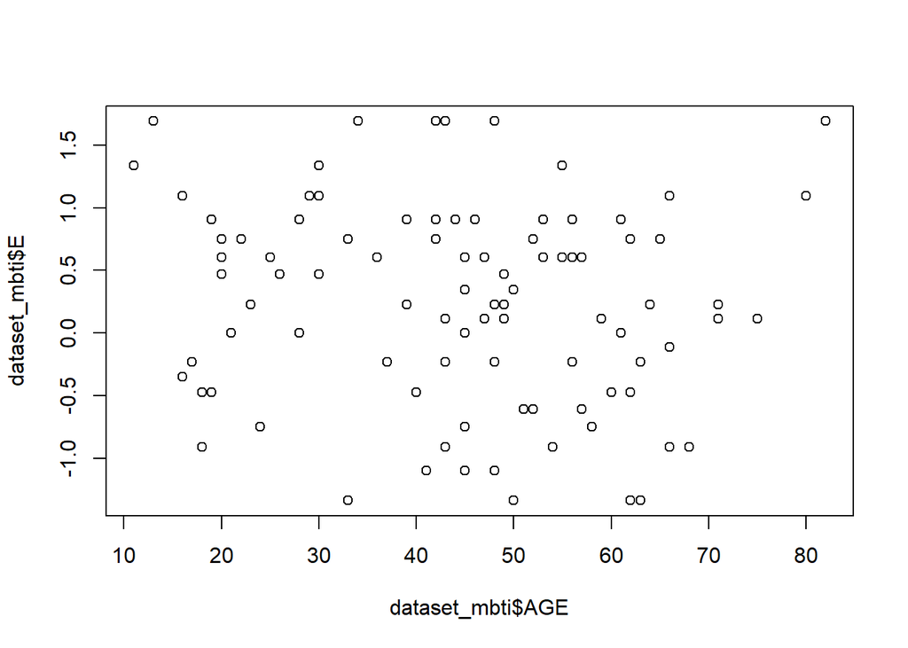

```r
plot(dataset_mbti$AGE, dataset_mbti$E)
```

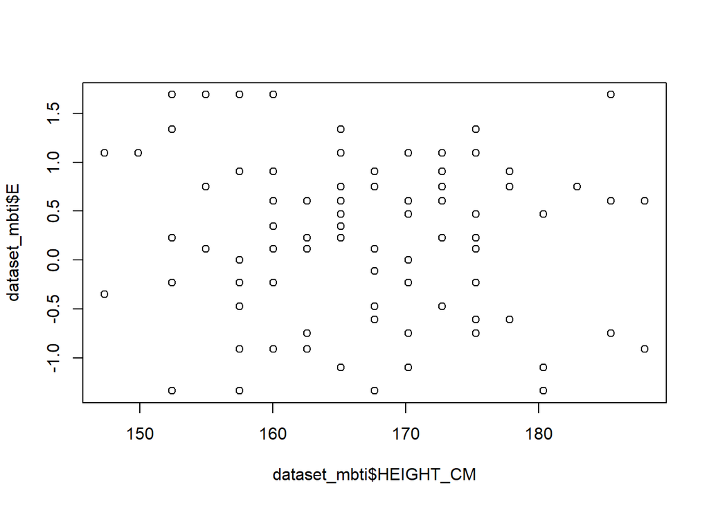

```r
plot(dataset_mbti$HEIGHT_CM, dataset_mbti$E)
```

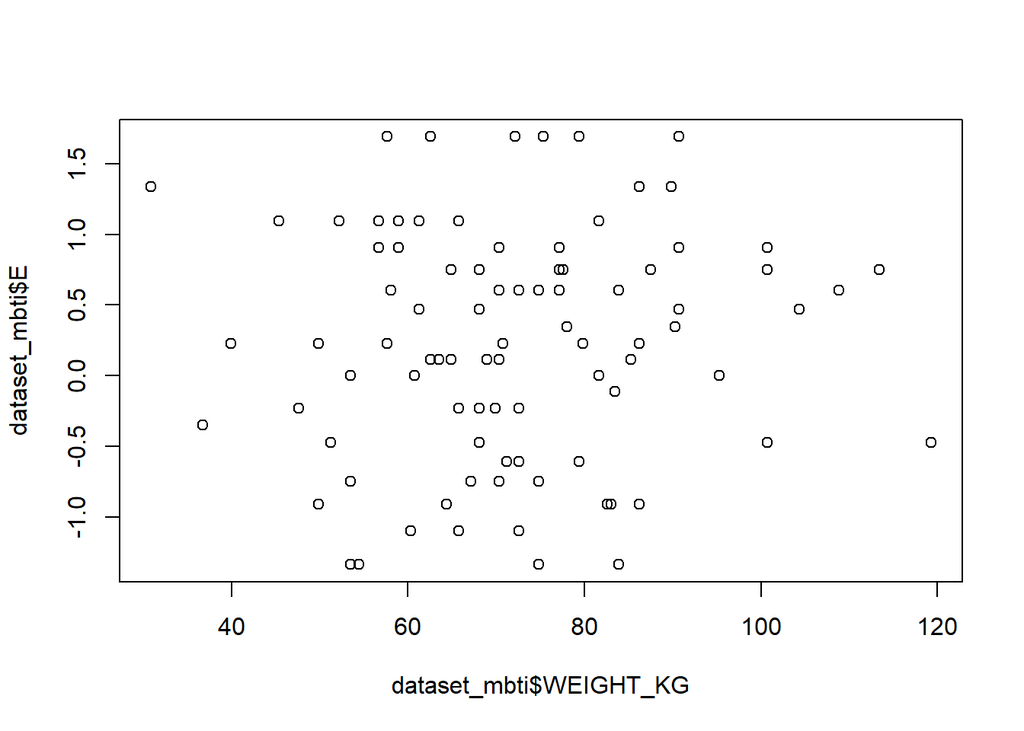

```r
plot(dataset_mbti$WEIGHT_KG, dataset_mbti$E)
```

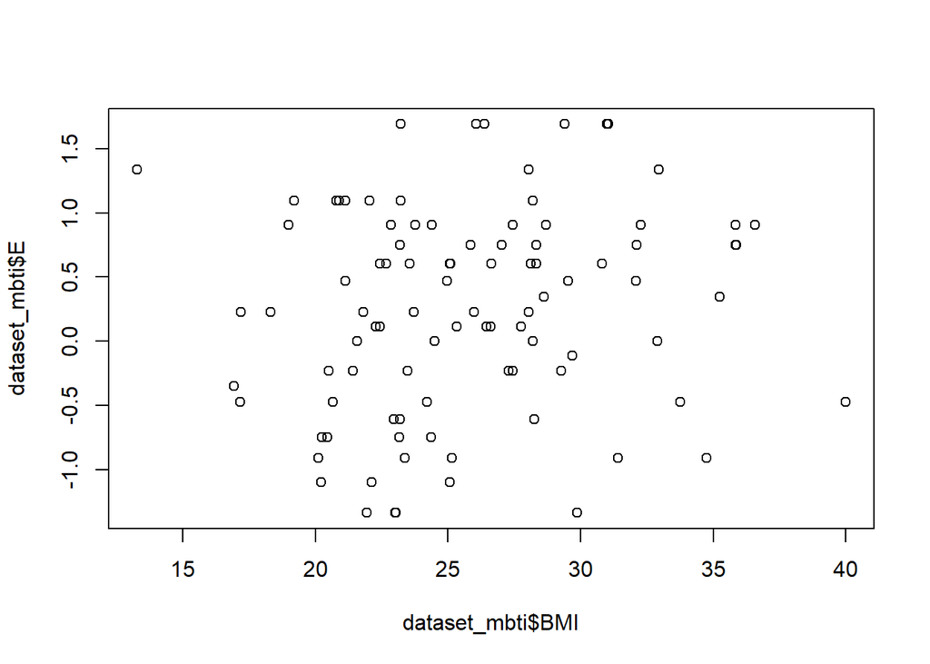

```r
plot(dataset_mbti$BMI, dataset_mbti$E)
```

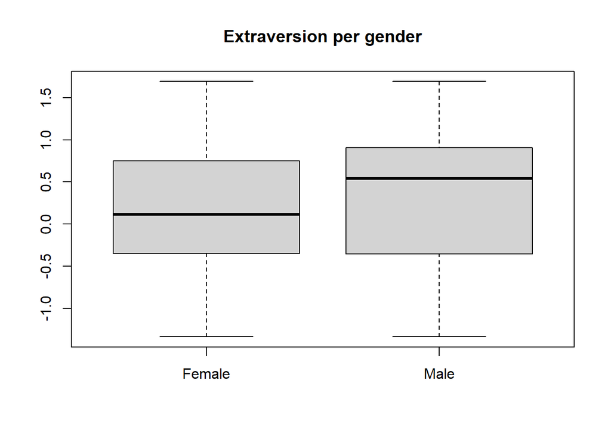

```r
boxplot(dataset_mbti[dataset_mbti$SEX == "Female",]$E,
        dataset_mbti[dataset_mbti$SEX == "Male",]$E,
        names = c("Female", "Male"),
        main = "Extraversion per gender")
```

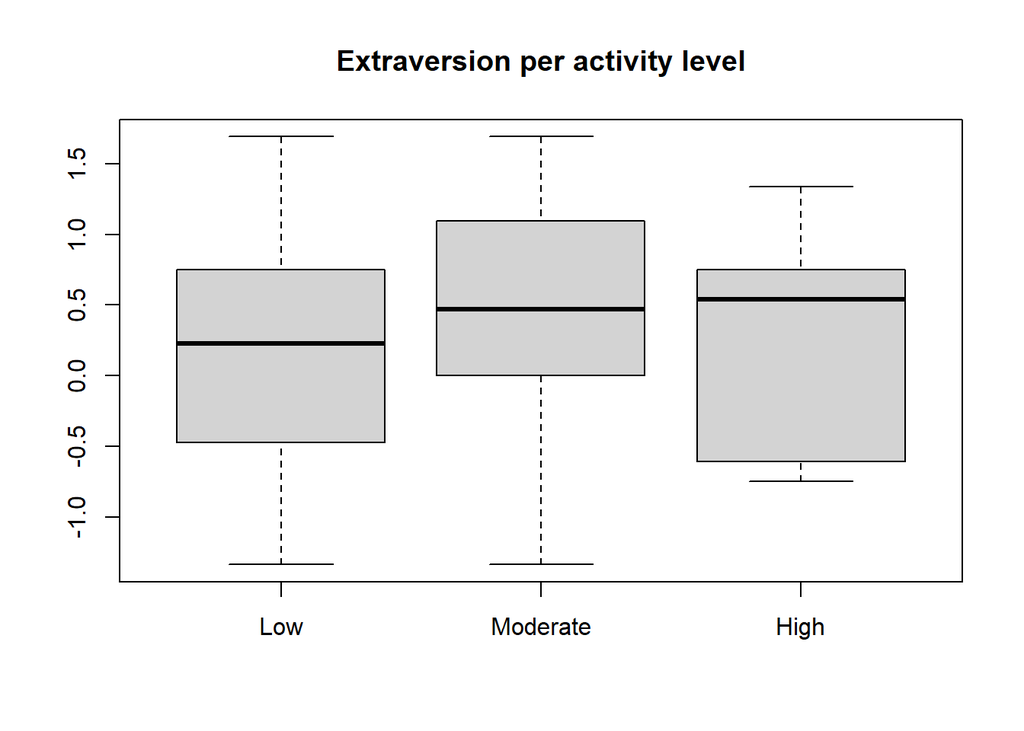

```r
boxplot(dataset_mbti[dataset_mbti$ACTIVITY.LEVEL == "Low",]$E,
        dataset_mbti[dataset_mbti$ACTIVITY.LEVEL == "Moderate",]$E,
        dataset_mbti[dataset_mbti$ACTIVITY.LEVEL == "High",]$E,
        names = c("Low", "Moderate", "High"),
        main = "Extraversion per activity level")
```

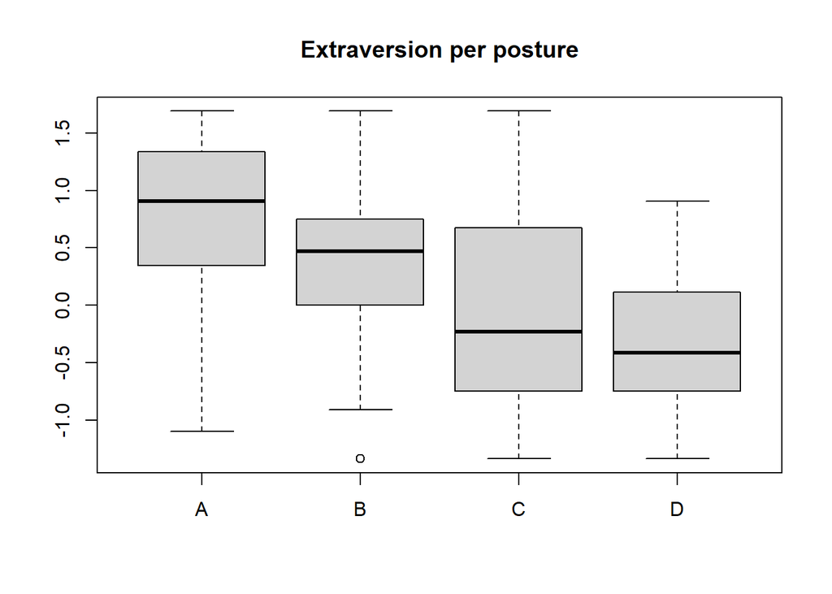

```r
boxplot(dataset_mbti[dataset_mbti$POSTURE == "A",]$E,
        dataset_mbti[dataset_mbti$POSTURE == "B",]$E,
        dataset_mbti[dataset_mbti$POSTURE == "C",]$E,
        dataset_mbti[dataset_mbti$POSTURE == "D",]$E,
        names = c("A", "B", "C", "D"),
        main = "Extraversion per posture")
```

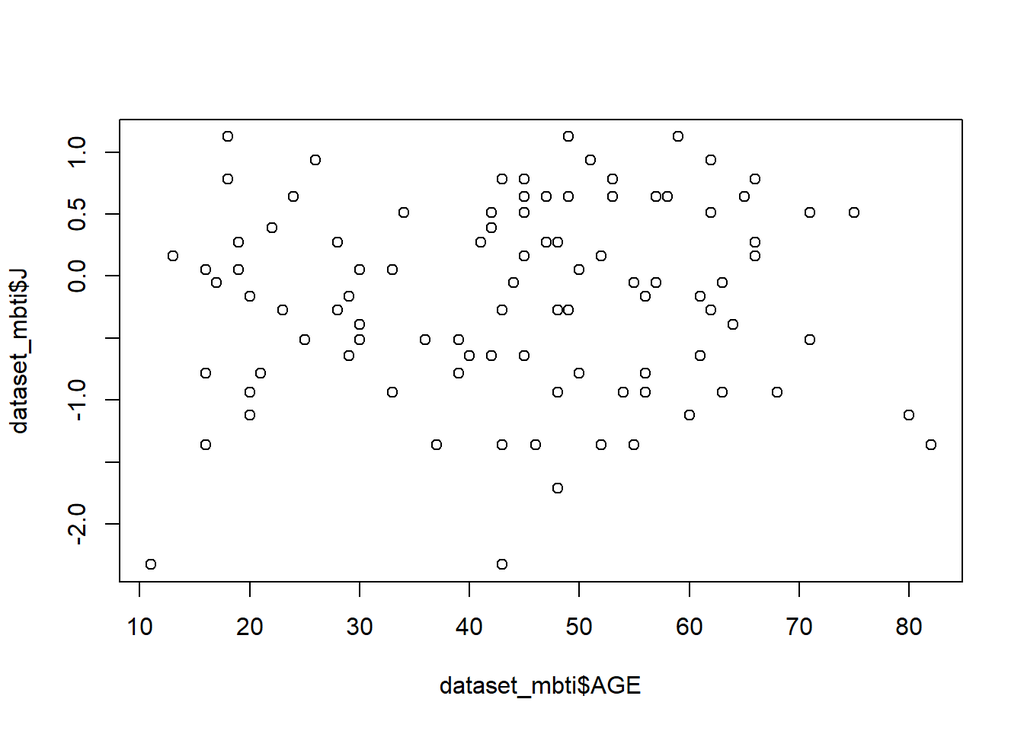

```r
plot(dataset_mbti$AGE, dataset_mbti$J)
```

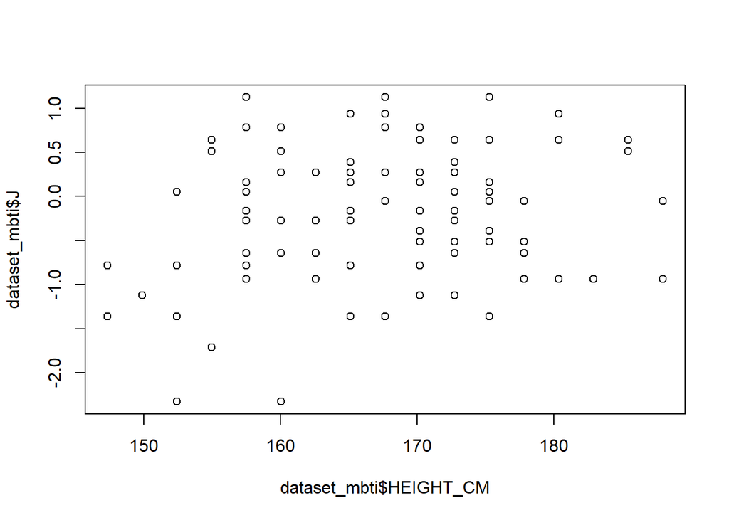

```r
plot(dataset_mbti$HEIGHT_CM, dataset_mbti$J)
```

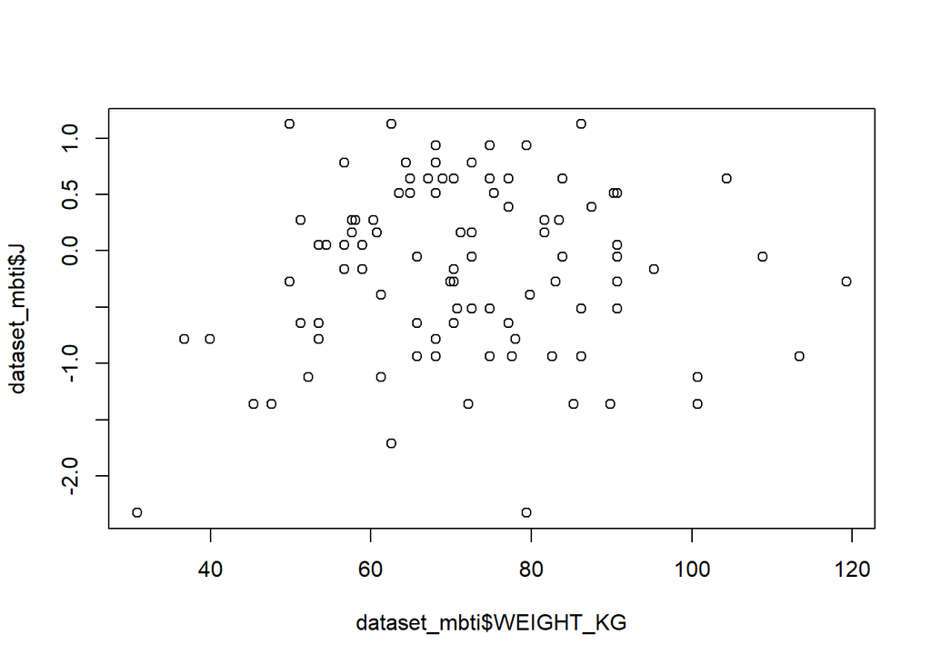

```r
plot(dataset_mbti$WEIGHT_KG, dataset_mbti$J)
```

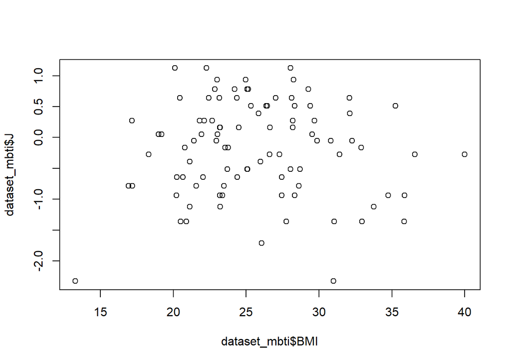

```r
plot(dataset_mbti$BMI, dataset_mbti$J)
```

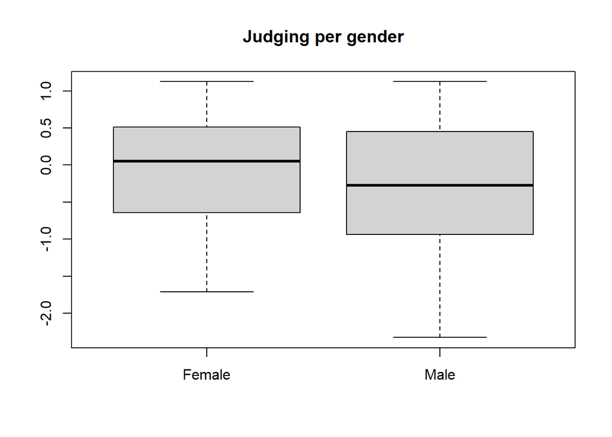

```r
boxplot(dataset_mbti[dataset_mbti$SEX == "Female",]$J,
        dataset_mbti[dataset_mbti$SEX == "Male",]$J,
        names = c("Female", "Male"),
        main = "Judging per gender")
```

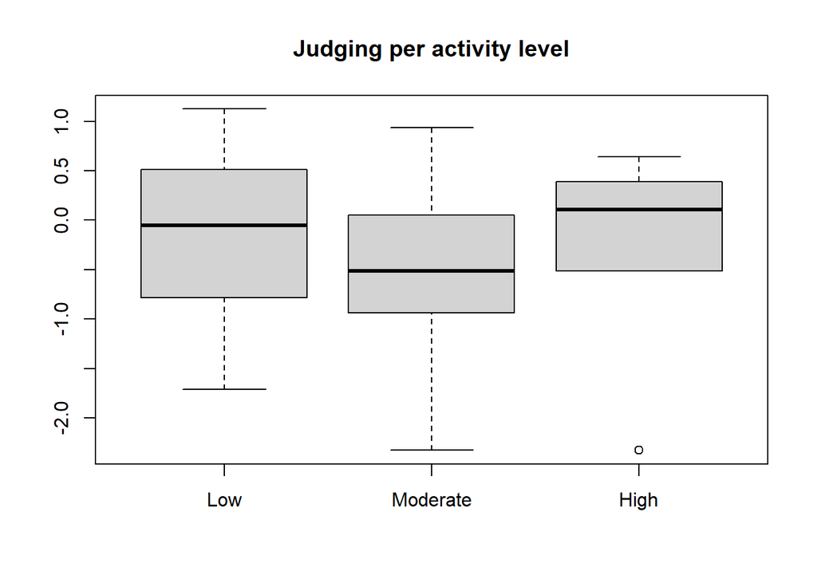

```r
boxplot(dataset_mbti[dataset_mbti$ACTIVITY.LEVEL == "Low",]$J,
        dataset_mbti[dataset_mbti$ACTIVITY.LEVEL == "Moderate",]$J,
        dataset_mbti[dataset_mbti$ACTIVITY.LEVEL == "High",]$J,
        names = c("Low", "Moderate", "High"),
        main = "Judging per activity level")
```

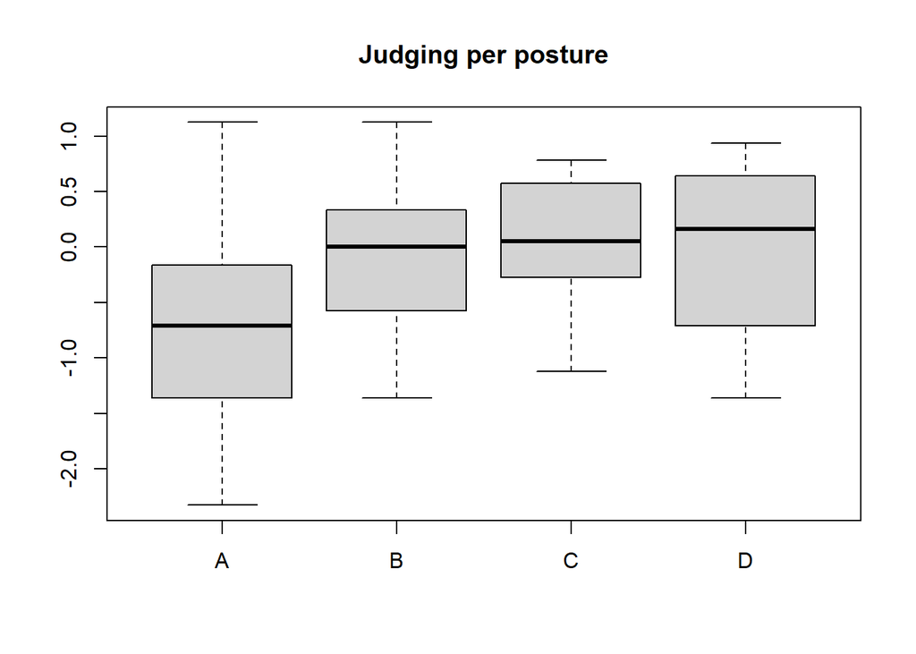

```r
boxplot(dataset_mbti[dataset_mbti$POSTURE == "A",]$J,
        dataset_mbti[dataset_mbti$POSTURE == "B",]$J,
        dataset_mbti[dataset_mbti$POSTURE == "C",]$J,
        dataset_mbti[dataset_mbti$POSTURE == "D",]$J,
        names = c("A", "B", "C", "D"),
        main = "Judging per posture")
```

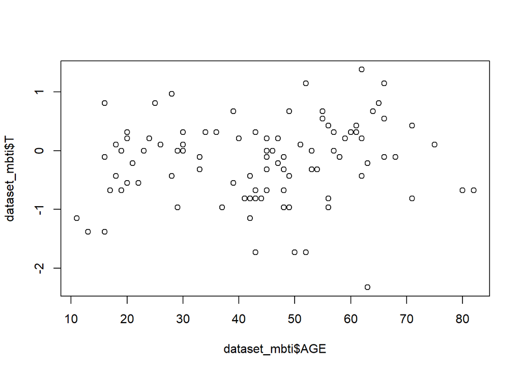

```r
plot(dataset_mbti$AGE, dataset_mbti$T)
```

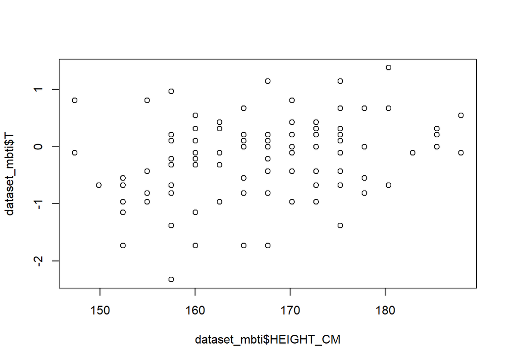

```r
plot(dataset_mbti$HEIGHT_CM, dataset_mbti$T)
```

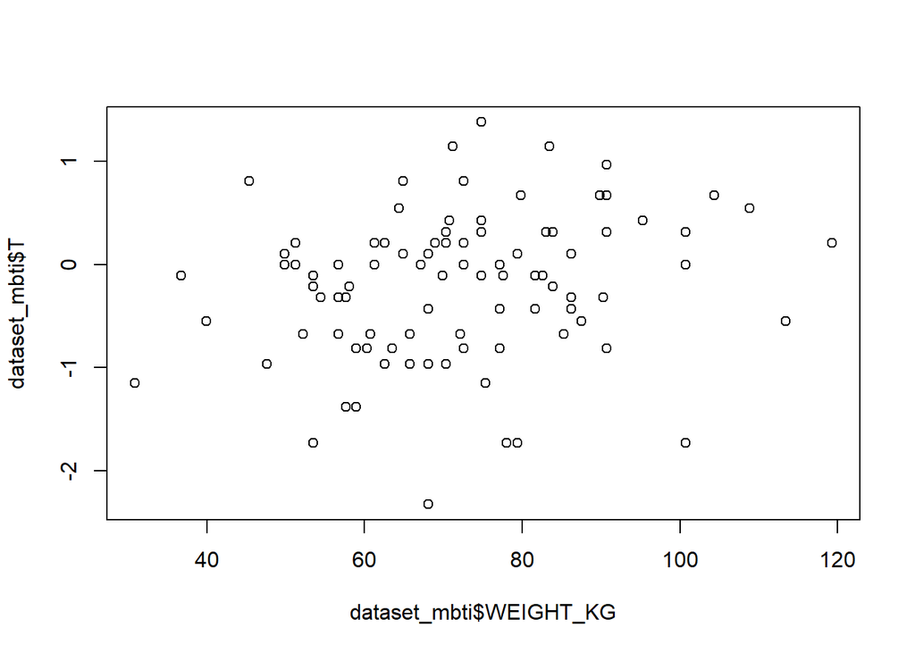

```r
plot(dataset_mbti$WEIGHT_KG, dataset_mbti$T)
```

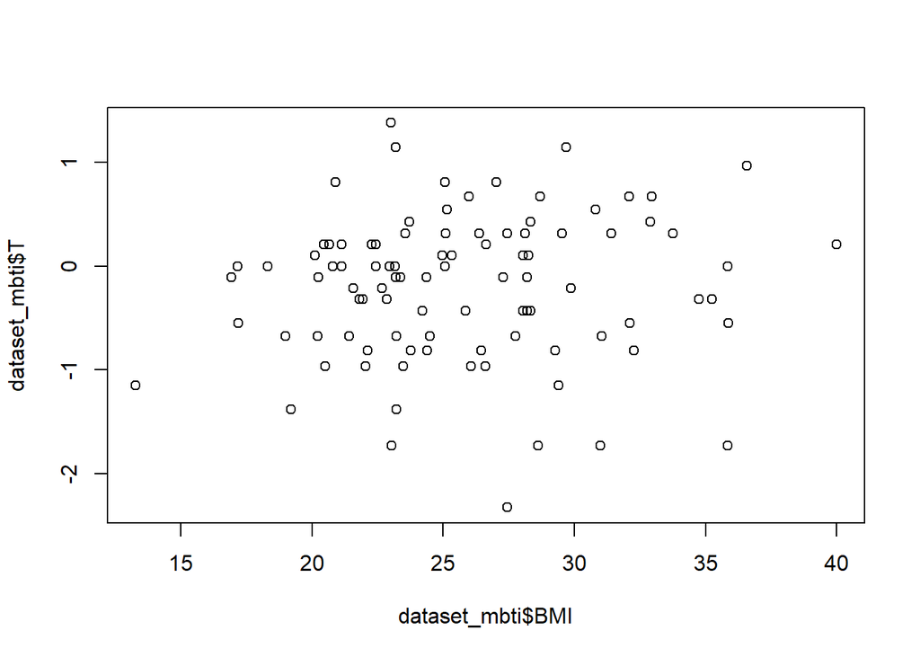

```r
plot(dataset_mbti$BMI, dataset_mbti$T)
```